# Comparison escapees vs non-escapees

# 1. Data loading and fast exploration by PCA

Loading bsseq objects

```r
bsseq_obj <- readRDS("~/EGCLCclones/2.PreliminaryAnalysis/bsseq_obj.rds")
bsseq_obj_escapees <- readRDS(paste0(params$InputFolder, "bsseq_obj_escapees.rds"))
bsseq_obj_NonEscapees <- readRDS(paste0(params$InputFolder, "bsseq_obj_NonEscapees.rds"))
```

**Colors for figures**

```r
cellTypes_colors <- c(hiPSCs ="#dd1c77", iMeLCs ="#377eb8", hPGCLCs ="#4daf4a", hEGCLCs_p5 = "#ff7f00", hEGCLCs_p10 = "#ffc400")
```

## PCA only on escapee CpGs

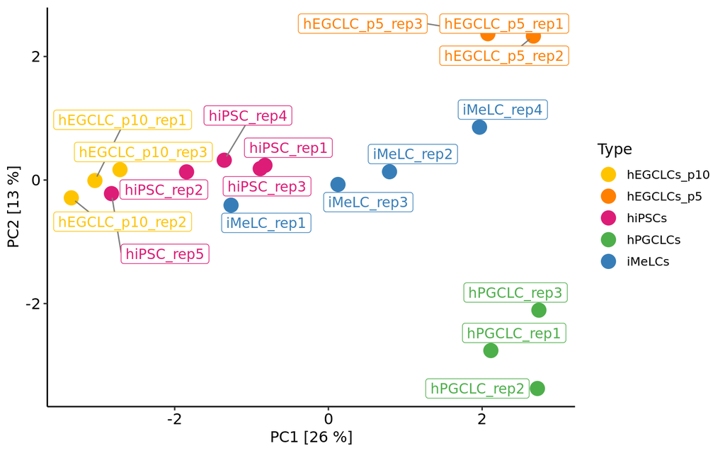

```r
pca_res <- do_PCA(getMeth(bsseq_obj_escapees, type = "raw"))
sample_anno <- bsseq::pData(bsseq_obj_escapees)
plot_PCA(pca_res = pca_res, anno = sample_anno, col_anno = "Type", shape_anno = NULL, custom_colors = cellTypes_colors, point_size = 5, show_labels = TRUE)
```

## PCA only on non-escapee CpGs

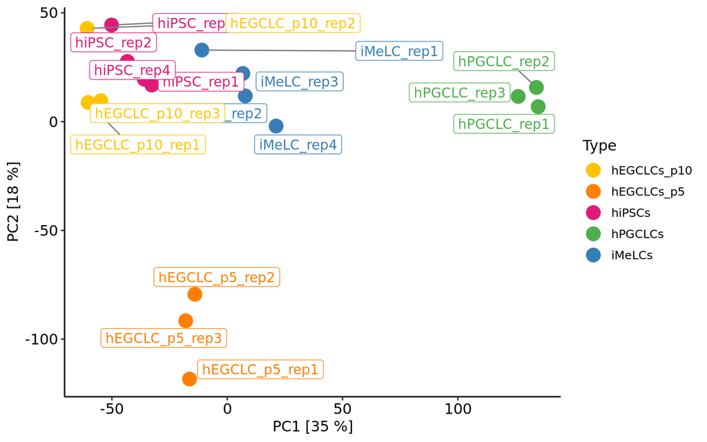

```r
pca_res <- do_PCA(getMeth(bsseq_obj_NonEscapees, type = "raw"))
sample_anno <- bsseq::pData(bsseq_obj_NonEscapees)
plot_PCA(pca_res = pca_res, anno = sample_anno, col_anno = "Type", shape_anno = NULL, custom_colors = cellTypes_colors, point_size = 5, show_labels = TRUE)
```

As expected it resembles the PCA done on the complete one, since we removed only 8941 out of a total of 3734728 CpG loci.

# 2.Generation of 500 random sets of 8941 non-escapee CpGs and distributions plots

Let’s generate random indices to randomly select 8941 CpG loci among the non-escapee ones.

```r
random_sets <- list()

for (i in 1:num_permutations) {
  random_indices <- sample(1:dim(bsseq_obj_NonEscapees)[1], dim(bsseq_obj_escapees)[1], replace = FALSE)
  bsseq_obj_randomNonEscapees <- bsseq_obj_NonEscapees[random_indices, ]

  random_sets[[i]] <- bsseq_obj_randomNonEscapees
}
```

**Head of BSSEQ with escapee CpGs**

```r
getMeth(bsseq_obj_escapees, type = "raw") %>% head()
```

```
##      hiPSC_rep1 hiPSC_rep2 hiPSC_rep3 hiPSC_rep4 hiPSC_rep5 iMeLC_rep1
## [1,]  0.9545455  0.9473684  0.9482759  0.9821429  0.9473684  0.9767442
## [2,]  1.0000000  0.9803922  0.9615385  0.9800000  0.9797980  0.9714286
## [3,]  0.8684211  0.9298246  0.7313433  0.8985507  0.8620690  0.9090909
## [4,]  0.8888889  0.9166667  0.8666667  0.9090909  0.8875000  0.9600000
## [5,]  0.7500000  0.8431373  0.8163265  0.7083333  0.8260870  0.8372093
## [6,]  0.8000000  0.8095238  0.8260870  0.8260870  0.8333333  0.8750000
##      iMeLC_rep2 iMeLC_rep3 iMeLC_rep4 hPGCLC_rep1 hPGCLC_rep2 hPGCLC_rep3
## [1,]  0.9813084  0.8909091  0.9534884   0.9062500   1.0000000   0.9428571
## [2,]  0.9622642  0.9230769  0.9032258   0.9600000   0.9545455   0.9677419
## [3,]  0.7758621  0.7608696  0.8666667   0.8108108   0.6969697   0.7948718
## [4,]  0.8198198  0.8297872  0.8666667   0.8437500   0.7741935   0.8837209
## [5,]  0.8461538  0.7894737  0.7333333   0.7307692   0.7272727   0.8378378
## [6,]  0.6551724  0.9000000  0.8500000   0.8750000   0.8947368   0.6944444
##      hEGCLC_p5_rep1 hEGCLC_p5_rep2 hEGCLC_p5_rep3 hEGCLC_p10_rep1
## [1,]      0.9230769      0.9081633      0.9318182       0.9425287
## [2,]      0.9850746      0.9484536      0.9594595       0.9827586
## [3,]      0.8426966      0.8750000      0.8400000       0.8939394
## [4,]      0.8571429      0.8450704      0.8311688       0.8928571
## [5,]      0.7333333      0.6949153      0.8730159       0.8896552
## [6,]      0.7812500      0.7692308      0.8888889       0.8358209
##      hEGCLC_p10_rep2 hEGCLC_p10_rep3
## [1,]       0.9607843       0.9487179
## [2,]       0.9775281       1.0000000
## [3,]       0.9021739       0.8895349
## [4,]       0.9210526       0.8742857
## [5,]       0.8226950       0.8500000
## [6,]       0.8367347       0.9333333
```

**Escapee CpG methylation distribution plot**

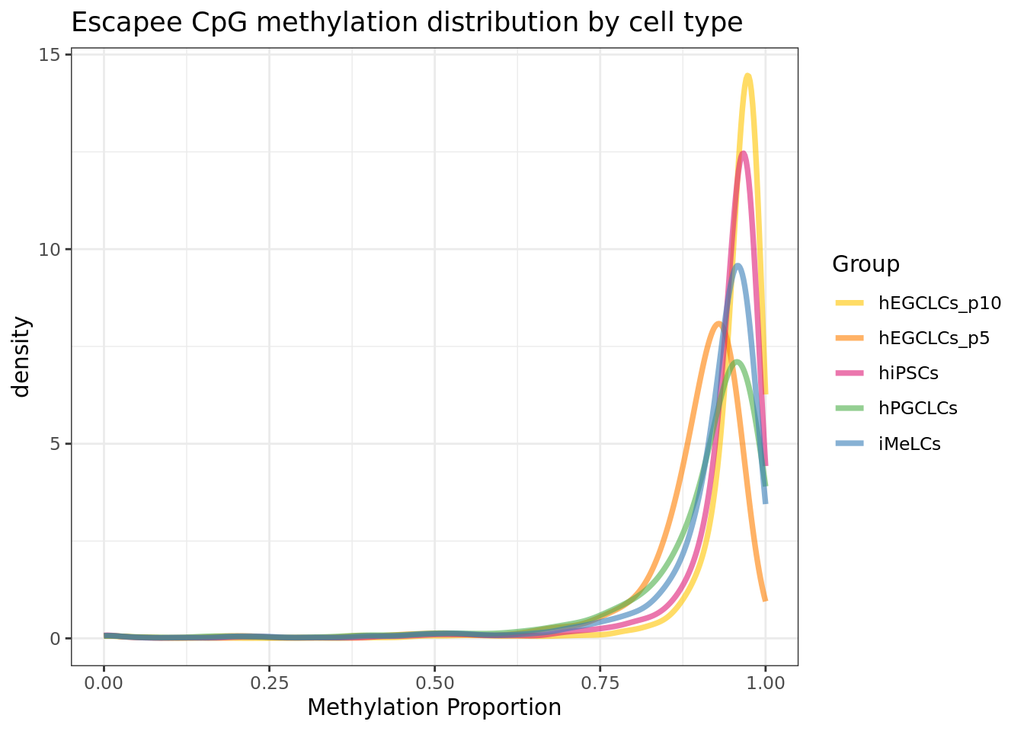

```r
plotEmpiricalDistribution(bsseq_obj_escapees,
                          bySample = FALSE,
                          testCovariate = "Type",
                          adj = 3) + guides(linetype="none") +
  labs(title = "Escapee CpG methylation distribution by cell type") + ggplot2::scale_color_manual(values = cellTypes_colors)
```

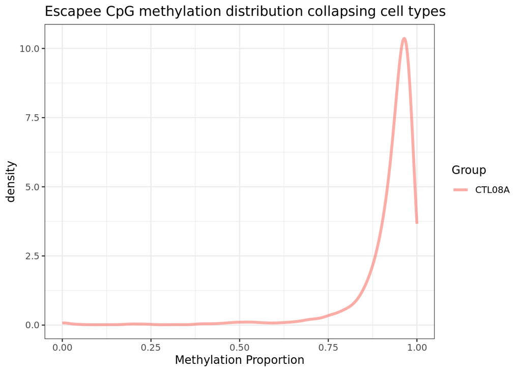

```r
plotEmpiricalDistribution(bsseq_obj_escapees,
                          bySample = FALSE,
                          testCovariate = "Line",
                          adj = 3) + guides(linetype="none") +
  labs(title = "Escapee CpG methylation distribution collapsing cell types")
```

**Non-Escapee CpG methylation distribution plot**

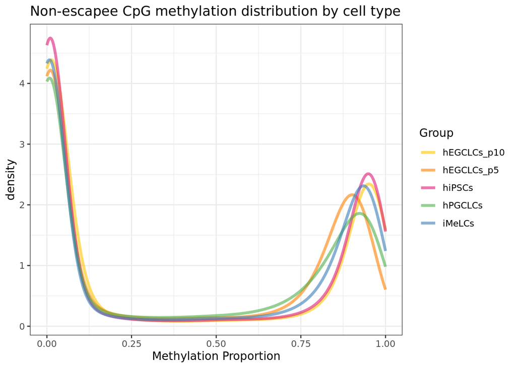

```r
plotEmpiricalDistribution(bsseq_obj_NonEscapees,
                          bySample = FALSE,
                          testCovariate = "Type",
                          adj = 3) + guides(linetype="none") +
  labs(title = "Non-escapee CpG methylation distribution by cell type") + ggplot2::scale_color_manual(values = cellTypes_colors)
```

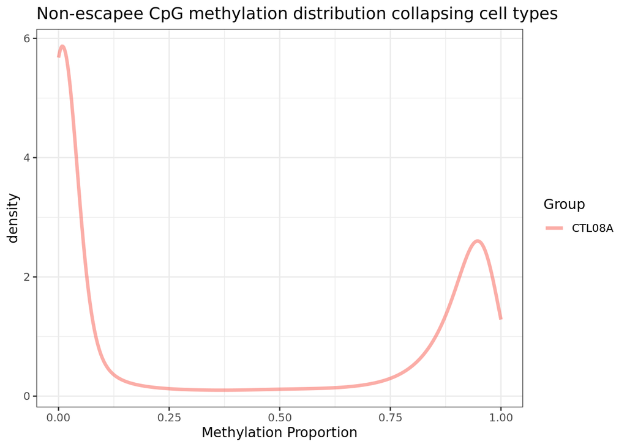

```r
plotEmpiricalDistribution(bsseq_obj_NonEscapees,
                          bySample = FALSE,
                          testCovariate = "Line",
                          adj = 3) + guides(linetype="none") +
  labs(title = "Non-escapee CpG methylation distribution collapsing cell types")
```

**Head of first BSSEQ with randomly selected non-escapee CpGs**

```r
getMeth(random_sets[[1]], type = "raw") %>% head()
```

```
##      hiPSC_rep1 hiPSC_rep2 hiPSC_rep3 hiPSC_rep4  hiPSC_rep5 iMeLC_rep1
## [1,] 0.01694915 0.03125000 0.02272727 0.01162791 0.031413613 0.01785714
## [2,] 0.05405405 0.02173913 0.02439024 0.00000000 0.022875817 0.04255319
## [3,] 0.00000000 0.00000000 0.00000000 0.00000000 0.002808989 0.00000000
## [4,] 1.00000000 1.00000000 1.00000000 1.00000000 1.000000000 1.00000000
## [5,] 0.52777778 0.48333333 0.50000000 0.61111111 0.704545455 0.53488372
## [6,] 0.05555556 0.00000000 0.01923077 0.00000000 0.006172840 0.00000000
##       iMeLC_rep2 iMeLC_rep3 iMeLC_rep4 hPGCLC_rep1 hPGCLC_rep2 hPGCLC_rep3
## [1,] 0.007462687 0.01666667 0.04000000  0.02127660   0.0000000  0.05769231
## [2,] 0.022471910 0.00000000 0.01886792  0.02083333   0.0000000  0.00000000
## [3,] 0.000000000 0.00000000 0.00000000  0.00000000   0.0000000  0.01515152
## [4,] 1.000000000 0.95238095 0.95833333  0.90476190   1.0000000  1.00000000
## [5,] 0.510869565 0.63157895 0.57894737  0.42857143   0.5555556  0.59701493
## [6,] 0.000000000 0.00000000 0.00000000  0.00000000   0.0000000  0.03174603
##      hEGCLC_p5_rep1 hEGCLC_p5_rep2 hEGCLC_p5_rep3 hEGCLC_p10_rep1
## [1,]     0.01600000     0.06194690     0.03361345     0.047904192
## [2,]     0.03488372     0.01587302     0.01470588     0.032110092
## [3,]     0.00000000     0.00000000     0.00000000     0.000000000
## [4,]     0.92105263     0.94444444     0.96428571     1.000000000
## [5,]     0.36842105     0.48351648     0.41025641     0.700854701
## [6,]     0.01282051     0.00000000     0.00000000     0.004016064
##      hEGCLC_p10_rep2 hEGCLC_p10_rep3
## [1,]      0.02681992     0.028469751
## [2,]      0.01731602     0.009009009
## [3,]      0.03103448     0.004048583
## [4,]      0.94444444     1.000000000
## [5,]      0.81779661     0.693023256
## [6,]      0.04291845     0.009302326
```

**First set of randomly selected non-escapee CpG methylation distribution plot**

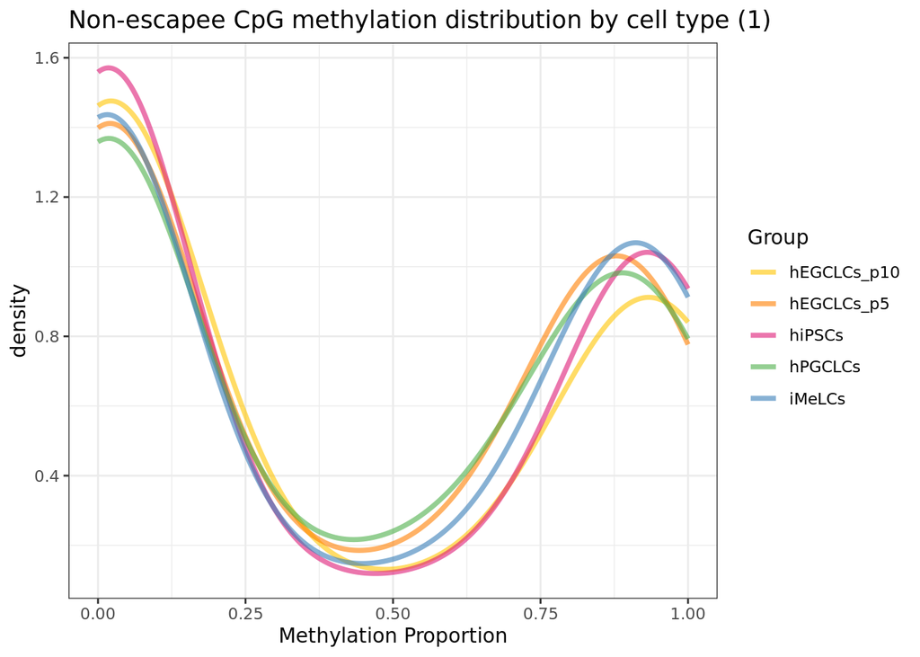

```r
plotEmpiricalDistribution(random_sets[[1]],
                          bySample = FALSE,
                          testCovariate = "Type",
                          adj = 3) + guides(linetype="none") +
  labs(title = "Non-escapee CpG methylation distribution by cell type (1)") + ggplot2::scale_color_manual(values = cellTypes_colors)
```

**Head of second BSSEQ with randomly selected non-escapee CpGs**

```r
getMeth(random_sets[[2]], type = "raw") %>% head()
```

```
##      hiPSC_rep1 hiPSC_rep2 hiPSC_rep3 hiPSC_rep4 hiPSC_rep5 iMeLC_rep1
## [1,]  0.9245283  0.9831933  0.8739496  0.9490446 0.95702479 0.96581197
## [2,]  0.0000000  0.0000000  0.0000000  0.0000000 0.00000000 0.02272727
## [3,]  0.9600000  0.9032258  0.8928571  0.9142857 0.96078431 0.96296296
## [4,]  0.0000000  0.0000000  0.0000000  0.0000000 0.01285347 0.00000000
## [5,]  0.9333333  0.9189189  0.9148936  0.8688525 0.93072289 0.98333333
## [6,]  0.9503546  0.9669604  0.9559748  0.9633333 0.94202899 0.96467391
##      iMeLC_rep2 iMeLC_rep3 iMeLC_rep4 hPGCLC_rep1 hPGCLC_rep2 hPGCLC_rep3
## [1,]  0.9322917 0.98290598  0.9558824  0.93333333   0.9142857  0.89333333
## [2,]  0.0000000 0.00000000  0.0000000  0.00000000   0.0000000  0.01923077
## [3,]  0.8367347 0.82142857  0.9047619  0.85185185   0.9090909  0.90322581
## [4,]  0.0000000 0.01111111  0.0000000  0.01694915   0.0000000  0.00000000
## [5,]  0.9107143 0.81034483  0.8709677  0.95652174   0.8965517  0.95348837
## [6,]  0.9367429 0.96167883  0.9443378  0.95693780   0.9655172  0.92073171
##      hEGCLC_p5_rep1 hEGCLC_p5_rep2 hEGCLC_p5_rep3 hEGCLC_p10_rep1
## [1,]     0.89784946     0.89171975    0.916666667     0.943025540
## [2,]     0.01428571     0.01204819    0.037037037     0.004608295
## [3,]     0.86792453     0.82692308    0.879310345     0.934782609
## [4,]     0.01398601     0.01459854    0.008849558     0.000000000
## [5,]     0.85869565     0.84523810    0.840909091     0.948529412
## [6,]     0.91095890     0.90218978    0.909433962     0.950000000
##      hEGCLC_p10_rep2 hEGCLC_p10_rep3
## [1,]     0.970183486     0.958236659
## [2,]     0.009950249     0.005555556
## [3,]     0.933333333     0.914285714
## [4,]     0.023529412     0.000000000
## [5,]     0.950226244     0.940476190
## [6,]     0.981132075     0.945454545
```

**Second set of randomly selected non-escapee CpG methylation distribution plot**

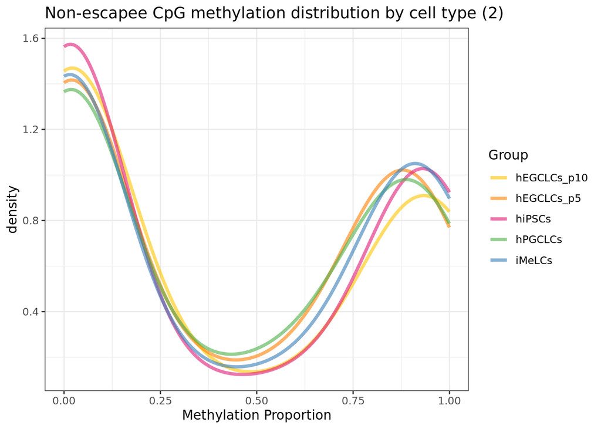

```r
plotEmpiricalDistribution(random_sets[[2]],
                          bySample = FALSE,
                          testCovariate = "Type",
                          adj = 3) + guides(linetype="none") +
  labs(title = "Non-escapee CpG methylation distribution by cell type (2)") + ggplot2::scale_color_manual(values = cellTypes_colors)
```

# 3. Kolmogorov-Smirnov test

Example of KS test result comparing distributions in case of hEGCLC_p10_rep1 sample: escapee CpG methylation levels vs first randomly selected non-escapee set.

```r
ks_test_result <- ks.test(getMeth(bsseq_obj_escapees, type = "raw")[, "hEGCLC_p10_rep1"], getMeth(random_sets[[1]], type = "raw")[, "hEGCLC_p10_rep1"])
print(ks_test_result)
```

```
##
##  Asymptotic two-sample Kolmogorov-Smirnov test
##
## data:  getMeth(bsseq_obj_escapees, type = "raw")[, "hEGCLC_p10_rep1"] and getMeth(random_sets[[1]], type = "raw")[, "hEGCLC_p10_rep1"]
## D = 0.50617, p-value < 2.2e-16
## alternative hypothesis: two-sided
```

Example of KS test result comparing distributions in case of hEGCLC_p10_rep1 sample: first randomly selected non-escapee set vs second randomly selected non-escapee set.

```r
ks_test_result <- ks.test(getMeth(random_sets[[1]], type = "raw")[, "hEGCLC_p10_rep1"], getMeth(random_sets[[2]], type = "raw")[, "hEGCLC_p10_rep1"])
print(ks_test_result)
```

```
##
##  Asymptotic two-sample Kolmogorov-Smirnov test
##
## data:  getMeth(random_sets[[1]], type = "raw")[, "hEGCLC_p10_rep1"] and getMeth(random_sets[[2]], type = "raw")[, "hEGCLC_p10_rep1"]
## D = 0.010185, p-value = 0.7498
## alternative hypothesis: two-sided
```

```r
ks_test_result <- ks.test(getMeth(random_sets[[1]], type = "raw")[, "hiPSC_rep5"], getMeth(random_sets[[1]], type = "raw")[, "hEGCLC_p10_rep3"])
print(ks_test_result)
```

```
##
##  Asymptotic two-sample Kolmogorov-Smirnov test
##
## data:  getMeth(random_sets[[1]], type = "raw")[, "hiPSC_rep5"] and getMeth(random_sets[[1]], type = "raw")[, "hEGCLC_p10_rep3"]
## D = 0.055911, p-value = 1.956e-12
## alternative hypothesis: two-sided
```

Example of KS test result comparing distributions: escapee CpG methylation levels vs first randomly selected non-escapee set **considering the mean levels across cell types (rowwise)**.

```r
ks_test_result <- ks.test(getMeth(bsseq_obj_escapees, type = "raw") %>% rowMeans(na.rm = TRUE), getMeth(random_sets[[1]], type = "raw") %>% rowMeans(na.rm = TRUE))
print(ks_test_result)
```

```
##
##  Asymptotic two-sample Kolmogorov-Smirnov test
##
## data:  getMeth(bsseq_obj_escapees, type = "raw") %>% rowMeans(na.rm = TRUE) and getMeth(random_sets[[1]], type = "raw") %>% rowMeans(na.rm = TRUE)
## D = 0.51214, p-value < 2.2e-16
## alternative hypothesis: two-sided
```

Example of KS test result comparing distributions: first randomly selected non-escapee set vs second randomly selected non-escapee set **considering the mean levels across cell types (rowwise)**.

```r
ks_test_result <- ks.test(getMeth(random_sets[[1]], type = "raw") %>% rowMeans(na.rm = TRUE), getMeth(random_sets[[2]], type = "raw") %>% rowMeans(na.rm = TRUE))
print(ks_test_result)
```

```
##
##  Asymptotic two-sample Kolmogorov-Smirnov test
##
## data:  getMeth(random_sets[[1]], type = "raw") %>% rowMeans(na.rm = TRUE) and getMeth(random_sets[[2]], type = "raw") %>% rowMeans(na.rm = TRUE)
## D = 0.011073, p-value = 0.6435
## alternative hypothesis: two-sided
```

*Let’s calculate the mean methylation levels across cell types in all sets of randomly selected non-escapee CpGs.*

```r
random_MeanMethLevels <- lapply(random_sets, function(bsseq){
  getMeth(bsseq, type = "raw") %>% rowMeans(na.rm = TRUE)})
```

**Let’s do KS test comparing escapee CpG methylation levels vs all 500 randomly selected non-escapee sets.**

```r
ks_test_results <- lapply(random_MeanMethLevels, function(random_MeanMeth) {
  ks.test(getMeth(bsseq_obj_escapees, type = "raw") %>% rowMeans(na.rm = TRUE), random_MeanMeth)
})
pvalues_kstest <- sapply(ks_test_results, function(result) {
  result$p.value
})
adjusted_pvalues_kstest <- p.adjust(pvalues_kstest, method = "fdr")
print(adjusted_pvalues_kstest)
```

```
##   [1] 0 0 0 0 0 0 0 0 0 0 0 0 0 0 0 0 0 0 0 0 0 0 0 0 0 0 0 0 0 0 0 0 0 0 0 0 0
##  [38] 0 0 0 0 0 0 0 0 0 0 0 0 0 0 0 0 0 0 0 0 0 0 0 0 0 0 0 0 0 0 0 0 0 0 0 0 0
##  [75] 0 0 0 0 0 0 0 0 0 0 0 0 0 0 0 0 0 0 0 0 0 0 0 0 0 0 0 0 0 0 0 0 0 0 0 0 0
## [112] 0 0 0 0 0 0 0 0 0 0 0 0 0 0 0 0 0 0 0 0 0 0 0 0 0 0 0 0 0 0 0 0 0 0 0 0 0
## [149] 0 0 0 0 0 0 0 0 0 0 0 0 0 0 0 0 0 0 0 0 0 0 0 0 0 0 0 0 0 0 0 0 0 0 0 0 0
## [186] 0 0 0 0 0 0 0 0 0 0 0 0 0 0 0 0 0 0 0 0 0 0 0 0 0 0 0 0 0 0 0 0 0 0 0 0 0
## [223] 0 0 0 0 0 0 0 0 0 0 0 0 0 0 0 0 0 0 0 0 0 0 0 0 0 0 0 0 0 0 0 0 0 0 0 0 0
## [260] 0 0 0 0 0 0 0 0 0 0 0 0 0 0 0 0 0 0 0 0 0 0 0 0 0 0 0 0 0 0 0 0 0 0 0 0 0
## [297] 0 0 0 0 0 0 0 0 0 0 0 0 0 0 0 0 0 0 0 0 0 0 0 0 0 0 0 0 0 0 0 0 0 0 0 0 0
## [334] 0 0 0 0 0 0 0 0 0 0 0 0 0 0 0 0 0 0 0 0 0 0 0 0 0 0 0 0 0 0 0 0 0 0 0 0 0
## [371] 0 0 0 0 0 0 0 0 0 0 0 0 0 0 0 0 0 0 0 0 0 0 0 0 0 0 0 0 0 0 0 0 0 0 0 0 0
## [408] 0 0 0 0 0 0 0 0 0 0 0 0 0 0 0 0 0 0 0 0 0 0 0 0 0 0 0 0 0 0 0 0 0 0 0 0 0
## [445] 0 0 0 0 0 0 0 0 0 0 0 0 0 0 0 0 0 0 0 0 0 0 0 0 0 0 0 0 0 0 0 0 0 0 0 0 0
## [482] 0 0 0 0 0 0 0 0 0 0 0 0 0 0 0 0 0 0 0
```

How many adjusted p-values are < 0.05?

```r
table(adjusted_pvalues_kstest < 0.05)
```

```
##
## TRUE
##  500
```

**Let’s do KS test comparing first randomly selected non-escapee set vs all 500 randomly selected non-escapee sets.**

```r
ks_test_results <- lapply(random_MeanMethLevels, function(random_MeanMeth) {
  ks.test(random_MeanMethLevels[[1]], random_MeanMeth)
})
pvalues_kstest <- sapply(ks_test_results, function(result) {
  result$p.value
})
adjusted_pvalues_kstest <- p.adjust(pvalues_kstest, method = "fdr")
print(adjusted_pvalues_kstest)
```

```
##   [1] 1.0000000 0.9987232 0.9987232 0.9987232 0.9987232 0.9987232 0.9987232
##   [8] 0.9987232 0.9987232 0.9987232 0.9987232 0.9987232 0.9987232 0.9987232
##  [15] 0.9987232 0.9987232 0.9987232 0.9987232 0.9987232 0.9987232 0.9987232
##  [22] 0.9987232 0.9987232 0.9987232 0.9987232 0.9987232 0.9987232 0.9987232
##  [29] 0.9987232 0.9987232 0.9987232 0.9987232 0.9987232 0.9987232 0.9987232
##  [36] 0.9987232 0.9987232 0.9987232 0.9987232 0.9987232 0.9987232 0.9987232
##  [43] 0.9987232 0.9987232 0.9987232 0.9987232 0.9987232 0.9987232 0.9987232
##  [50] 0.9987232 0.9987232 0.9987232 0.9987232 0.9987232 0.9987232 0.9987232
##  [57] 0.9987232 0.9987232 0.9987232 0.9987232 0.9987232 0.9987232 0.9987232
##  [64] 0.9987232 0.9987232 0.9987232 0.9987232 0.9987232 0.9987232 0.9987232
##  [71] 0.9987232 0.9987232 0.9987232 0.9987232 0.9987232 0.9987232 0.9987232
##  [78] 0.9987232 0.9987232 0.9987232 0.9987232 0.9987232 0.9987232 0.9987232
##  [85] 0.9987232 0.9987232 0.9987232 0.9987232 0.9987232 0.9987232 0.9987232
##  [92] 0.9987232 0.9987232 0.9987232 0.9987232 0.9987232 0.9987232 0.9987232
##  [99] 0.9987232 0.9987232 0.9987232 0.9987232 0.9987232 0.9987232 0.9987232
```

[output cut: 57 more lines]

How many adjusted p-values are < 0.05?

```r
table(adjusted_pvalues_kstest < 0.05)
```

```
##
## FALSE
##   500
```

# 4.Escapee and non escapee CpG methylation distribution plot

```r
MeanMethLevels_df <- c(unlist(random_MeanMethLevels), getMeth(bsseq_obj_escapees, type = "raw") %>% rowMeans(na.rm = TRUE) %>% as.vector()) %>% as.data.frame()
colnames(MeanMethLevels_df) <- "MeanMeth"
MeanMethLevels_df$Distribution <- c(paste0("Random_", rep(1:num_permutations, each = dim(bsseq_obj_escapees)[1])), rep("Escapees_CpGs", each = dim(bsseq_obj_escapees)[1]))
MeanMethLevels_df$Category <- "Non Escapees"
MeanMethLevels_df$Category[(nrow(MeanMethLevels_df)+1-nrow(bsseq_obj_escapees)):nrow(MeanMethLevels_df)] <- "Escapees"
```

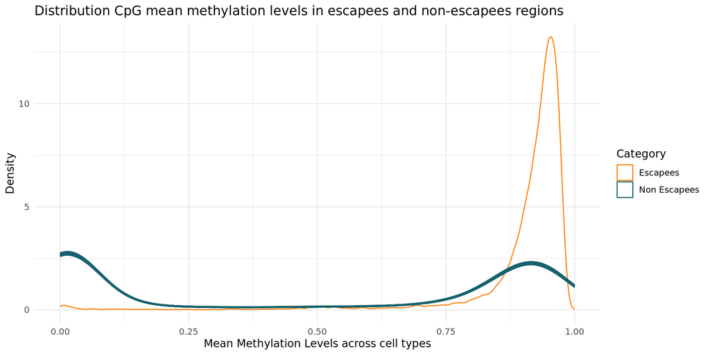

```r
ggplot(MeanMethLevels_df, aes(x = MeanMeth, color = Category, group = Distribution)) +
  geom_density(alpha = 0.5)  +
  labs(
    title = "Distribution CpG mean methylation levels in escapees and non-escapees regions",
    x = "Mean Methylation Levels across cell types",
    y = "Density",
    color = "Category"
  ) +
  scale_color_manual(values = c("Escapees" = "#FF7D00", "Non Escapees" = "#15616D")) +
  theme_minimal()
```

# 5.Session Info

```r
date()
## [1] "Thu Jul 24 16:02:20 2025"
sessionInfo()
## R version 4.2.1 (2022-06-23)
## Platform: x86_64-pc-linux-gnu (64-bit)
## Running under: Ubuntu 20.04.4 LTS
##
## Matrix products: default
## BLAS:   /usr/lib/x86_64-linux-gnu/blas/libblas.so.3.9.0
## LAPACK: /usr/lib/x86_64-linux-gnu/lapack/liblapack.so.3.9.0
##
## locale:
##  [1] LC_CTYPE=en_US.UTF-8       LC_NUMERIC=C
##  [3] LC_TIME=en_US.UTF-8        LC_COLLATE=en_US.UTF-8
##  [5] LC_MONETARY=en_US.UTF-8    LC_MESSAGES=en_US.UTF-8
##  [7] LC_PAPER=en_US.UTF-8       LC_NAME=C
##  [9] LC_ADDRESS=C               LC_TELEPHONE=C
## [11] LC_MEASUREMENT=en_US.UTF-8 LC_IDENTIFICATION=C
##
## attached base packages:
## [1] stats4    stats     graphics  grDevices utils     datasets  methods
## [8] base
##
## other attached packages:
##  [1] tidyr_1.3.0                 ggplot2_3.4.2
##  [3] dmrseq_1.18.1               bsseq_1.34.0
##  [5] SummarizedExperiment_1.28.0 Biobase_2.58.0
##  [7] MatrixGenerics_1.10.0       matrixStats_1.0.0
##  [9] GenomicRanges_1.50.2        GenomeInfoDb_1.34.9
## [11] IRanges_2.32.0              S4Vectors_0.36.2
## [13] BiocGenerics_0.44.0         dplyr_1.1.2
## [15] plyr_1.8.8
##
## loaded via a namespace (and not attached):
##   [1] AnnotationHub_3.6.0           BiocFileCache_2.6.1
##   [3] splines_4.2.1                 BiocParallel_1.32.6
##   [5] digest_0.6.33                 foreach_1.5.2
##   [7] htmltools_0.5.5               fansi_1.0.4
##   [9] magrittr_2.0.3                memoise_2.0.1
##  [11] BSgenome_1.66.3               tzdb_0.4.0
##  [13] limma_3.54.2                  Biostrings_2.66.0
##  [15] readr_2.1.4                   R.utils_2.12.2
##  [17] prettyunits_1.1.1             colorspace_2.1-0
##  [19] blob_1.2.4                    rappdirs_0.3.3
##  [21] ggrepel_0.9.3                 xfun_0.39
##  [23] crayon_1.5.2                  RCurl_1.98-1.12
##  [25] jsonlite_1.8.7                annotatr_1.24.0
##  [27] iterators_1.0.14              glue_1.6.2
##  [29] gtable_0.3.3                  zlibbioc_1.44.0
##  [31] XVector_0.38.0                DelayedArray_0.24.0
##  [33] Rhdf5lib_1.20.0               HDF5Array_1.26.0
##  [35] scales_1.2.1                  DBI_1.1.3
##  [37] rngtools_1.5.2                Rcpp_1.0.11
##  [39] xtable_1.8-4                  progress_1.2.2
##  [41] bumphunter_1.40.0             bit_4.0.5
##  [43] httr_1.4.6                    RColorBrewer_1.1-3
##  [45] ellipsis_0.3.2                pkgconfig_2.0.3
##  [47] XML_3.99-0.14                 R.methodsS3_1.8.2
##  [49] farver_2.1.1                  sass_0.4.7
##  [51] dbplyr_2.3.3                  locfit_1.5-9.7
##  [53] utf8_1.2.3                    tidyselect_1.2.0
##  [55] labeling_0.4.2                rlang_1.1.1
##  [57] reshape2_1.4.4                later_1.3.1
##  [59] AnnotationDbi_1.60.2          munsell_0.5.0
##  [61] BiocVersion_3.16.0            tools_4.2.1
##  [63] cachem_1.0.8                  cli_3.6.1
##  [65] generics_0.1.3                RSQLite_2.3.1
##  [67] evaluate_0.21                 stringr_1.5.0
##  [69] fastmap_1.1.1                 yaml_2.3.7
##  [71] outliers_0.15                 knitr_1.43
##  [73] bit64_4.0.5                   purrr_1.0.1
##  [75] KEGGREST_1.38.0               nlme_3.1-162
##  [77] doRNG_1.8.6                   sparseMatrixStats_1.10.0
##  [79] mime_0.12                     R.oo_1.25.0
##  [81] xml2_1.3.5                    biomaRt_2.54.1
##  [83] compiler_4.2.1                rstudioapi_0.15.0
##  [85] filelock_1.0.2                curl_5.0.1
##  [87] png_0.1-8                     interactiveDisplayBase_1.36.0
##  [89] tibble_3.2.1                  bslib_0.5.0
##  [91] stringi_1.7.12                highr_0.10
##  [93] GenomicFeatures_1.50.4        lattice_0.21-8
##  [95] Matrix_1.6-0                  permute_0.9-7
##  [97] vctrs_0.6.3                   pillar_1.9.0
##  [99] lifecycle_1.0.3               rhdf5filters_1.10.1
## [101] BiocManager_1.30.20           jquerylib_0.1.4
## [103] data.table_1.14.8             bitops_1.0-7
## [105] httpuv_1.6.11                 rtracklayer_1.58.0
## [107] R6_2.5.1                      BiocIO_1.8.0
## [109] promises_1.2.0.1              codetools_0.2-19
## [111] gtools_3.9.4                  rhdf5_2.42.1
## [113] rjson_0.2.21                  withr_2.5.0
## [115] regioneR_1.30.0               GenomicAlignments_1.34.1
## [117] Rsamtools_2.14.0              GenomeInfoDbData_1.2.9
## [119] parallel_4.2.1                hms_1.1.3
## [121] grid_4.2.1                    rmarkdown_2.23
## [123] DelayedMatrixStats_1.20.0     shiny_1.7.4.1
## [125] restfulr_0.0.15
```